# National Reservoir Methane Survey: R10

J. Beaulieu

12/16/2019

```r
# load libraries
library(sf) # spatial data
library(tidyverse) # dplyr, ggplot
library(USAboundaries)

# Load data, from Olsen
dsn <- read_sf("../..//output/surveyDsgnOutput/SuRGE_design_20191206.shp")
```

ORD and Region 10 have previously measured CH4 and CO2 emission rates from reservoirs in Washington, Idaho, and Oregon. The methods used during the surveys are identical to those that will be used for the new national survey. Any previously sampled sites that happen to be included in the new national survey will not be resampled.

## Region 10 sites

The new survey design contains 6 Base sites in R10. Two of these sites were sampled by R10 in 2018. Both sites are in the Western Mountains ecoregion and will not be resampled during this new survey.

```r
# SITE_ID and lake names of R10 surveyed reservoirs.
r10 <- c("NLA17_WA-10038", "Baker Lake",
         "NLA17_WA-10006", "Swofford Pond",
         "NLA17_WA-10002", "Wapato Lake",
         "NLA17_OR-10006", "Phillips Reservoir",
         "NLA17_ID-10175", "Mormon Reservoir",
         "NLA17_ID-10032", "Lower Goose Reservoir",
         "NLA17_ID-10007", "Springfield Reservoir")

r10 <- data.frame(SITE_ID = r10[seq(1, 13, 2)],
                  R10_NAME = r10[seq(2, 14, 2)],
                  stringsAsFactors = FALSE)

dsn %>% as.tibble() %>%
  filter(panel == "Base") %>% # only Base sites
  merge(., r10) %>% # bring in r10 sites
  select(SITE_ID, R10_NAME, panel, AG_ECO9) # show matches
```

| SITE_ID | R10_NAME | panel | AG_ECO9 |
| --- | --- | --- | --- |
| NLA17_OR-10006 | Phillips Reservoir | Base | WMT |
| NLA17_WA-10006 | Swofford Pond | Base | WMT |

This leaves 4 new sites to sample in R10.

```r
# New sites to sample in R10.
r10.new <- dsn %>% as.data.frame() %>%
  filter(panel == "Base", # only Base sites
         PSTL_CODE %in% c("WA", "OR", "ID"), # only in R10
         !(SITE_ID %in% c("NLA17_OR-10006", "NLA17_WA-10006"))) %>%
  select(SITE_ID, panel, AG_ECO9) # show matches

r10.new
```

| SITE_ID | panel | AG_ECO9 |
| --- | --- | --- |
| NLA17_OR-10003 | Base | WMT |
| NLA17_OR-10009 | Base | WMT |
| NLA17_ID-10168 | Base | WMT |
| NLA17_OR-10060 | Base | XER |

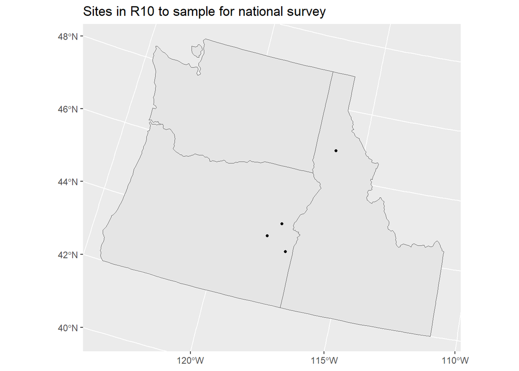

[output not shown]

| SITE_ID | R10_NAME | panel | AG_ECO9 |
| --- | --- | --- | --- |
| NLA17_ID-10007 | Springfield Reservoir | OverSamp | XER |
| NLA17_ID-10032 | Lower Goose Reservoir | OverSamp | XER |
| NLA17_ID-10175 | Mormon Reservoir | OverSamp | XER |
| NLA17_WA-10002 | Wapato Lake | OverSamp | XER |

It is possible that previously sampled R10 sites will be used as oversample sites, most likely in XER_GT_6m_LE_7 and XER_LE_6m_LE_7.

```r
# Oversample sites in XERIC ecoregion.
dsn %>% as.tibble() %>%
  filter(panel == "OverSamp", AG_ECO9 == "XER") %>%
  select(siteID, stratum, panel, SITE_ID, AG_ECO9) %>%
  print(n= Inf)
```

```
## # A tibble: 40 x 5
##    siteID  stratum        panel    SITE_ID        AG_ECO9
##    <chr>   <chr>          <chr>    <chr>          <chr>
##  1 CH4-288 XER_GT_6m_GT_7 OverSamp NLA17_AZ-10001 XER
##  2 CH4-289 XER_GT_6m_GT_7 OverSamp NLA17_CA-10005 XER
##  3 CH4-290 XER_GT_6m_GT_7 OverSamp NLA17_ID-10005 XER
##  4 CH4-291 XER_GT_6m_GT_7 OverSamp NLA17_CA-10011 XER
##  5 CH4-292 XER_GT_6m_GT_7 OverSamp NLA17_WY-10018 XER
##  6 CH4-293 XER_GT_6m_GT_7 OverSamp NLA17_AZ-10005 XER
##  7 CH4-294 XER_GT_6m_GT_7 OverSamp NLA17_ID-10002 XER
##  8 CH4-295 XER_GT_6m_GT_7 OverSamp NLA17_TX-10021 XER
##  9 CH4-299 XER_GT_6m_LE_7 OverSamp NLA17_ID-10011 XER
## 10 CH4-300 XER_GT_6m_LE_7 OverSamp NLA17_NM-10024 XER
## 11 CH4-301 XER_GT_6m_LE_7 OverSamp NLA17_CA-10008 XER
## 12 CH4-302 XER_GT_6m_LE_7 OverSamp NLA17_ID-10032 XER
```

[output cut: 28 more lines]